# Zipf’s Law, and its Occurrences

Zipf’s Law, and its Occurrences Jason Chhay 1/15/2020

#### [Back to projects page](https://jwchhay.github.io/projects.html)

## So… What is Zipf’s Law?

**First, the following two datasets is from https://en.wiktionary.org/wiki/Wiktionary:Frequency_lists and I think it’s a fun read. Anyways, the first is under “Specific TV series dictionaries” under the English section. The second is under “Japanese Wikipedia 2015” under the Japanese section. I look at the top 10000 words which can be acquired as a .tsv file.**

There is a phenomena I learned in a linguistics class I’ve taken called “Zipf’s Law”. This is probably one of the few linguistic-statistic topics that exists (which is very exciting for me), but I find it difficult to explain in words. So, I think an example is better at explaining:

There is a chart online that I found via Wikipedia where it shows the frequency of words spoken on the television series “The Simpsons” (or at least written within the dialogue). The top 10 looks like:

```
##    Rank Word Frequency
## 1     1  the    107946
## 2     2  you     98068
## 3     3    I     91502
## 4     4    a     79241
## 5     5   to     70362
## 6     6  and     47916
## 7     7   of     42175
## 8     8   it     36497
## 9     9   in     32503
## 10   10   my     32254
```

As you can see, the most common word found in the show (up to some episode in 2012, based on the data’s age) is the word “the”. If you graphed the words with their individual frequencies, you get a logarithmic pattern.

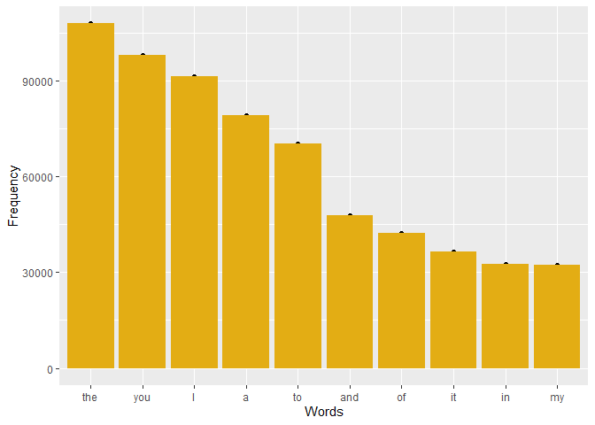

Let’s look at Wikipedia’s word frequency list for Japanese. Here, the logarithmic pattern is much more noticeable. This is because the amount of words is higher, and the frequencies are well within the millions.

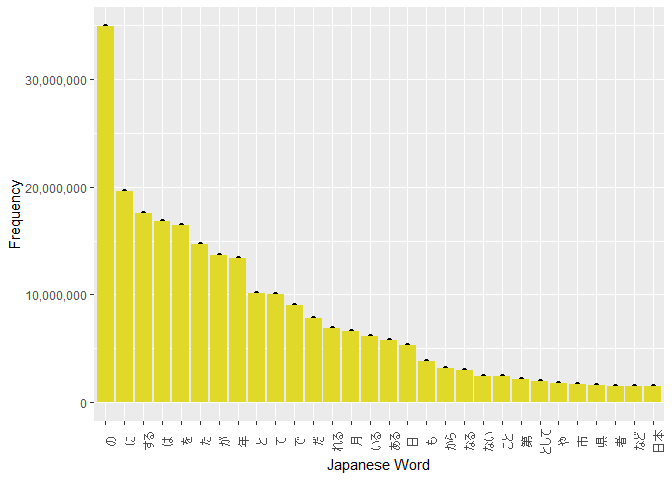

Notice that the data comes from Wikipedia, which I’d say is a fairly formally written source. Also, Japanese is notorious for having several different forms of formality in written and spoken Japanese. I am under the impression that the Japanese Wikipedia is written fairly formally as well.

Essentially, Zipf’s law states that the rank of words in a given language are inversely proportional to their frequencies. This kind of distribution occurs in other disciplines unrelated to linguistics, and it is literally called a Zipfian distribution. I’ll just leave a link on Wikipedia for those interested in more of its properties. https://en.wikipedia.org/wiki/Zipf%27s_law

## Now Onwards To The Meat and Potatoes (My Hypothesis)

I now want to bring attention to why I’m looking at Zipf’s law. I have a gut feeling that the most frequent words in Wikipedia are quite different from the most frequent words found on something like Twitter. There are bound to be some words that are just generally common, like “the” or “a”. However, I highly doubt the rank of a word like “lol” is higher on Wikipedia than on social media. Also, one question in my mind is “do these words serve the same syntacic purpose based on their rank?” I’d like to see if the words in both sets have the same relative number of words like determiners (“words like”the" or “a”), verbs, adverbs, etc.

With that mentality in mind, I’ll be analyzing English words found on Wikipedia and Twitter, since I’m an English speaker. I am aware that there may be analysis done on something like this already; however, I’ll leave it as a surprise for myself to find out. Also, I think it’ll serve as good practice.

There are also some interesting phenomena with Zipf’s law. As per Wikipedia’s article on word frequency:

https://en.wikipedia.org/wiki/Word_lists_by_frequency#Statistics

“German linguists define the Häufigkeitsklasse (frequency class) $N$ of an item in the list using the base 2 logarithm of the ratio between its frequency and the frequency of the most frequent item. The most common item belongs to frequency class 0 (zero) and any item that is approximately half as frequent belongs in class 1.”

$N = \left \lfloor{0.5 - \log_2(\frac{\text{Frequency of item}}{\text{Frequency of most common item}})}\right \rfloor$

I’ll come back to this equation at a later time *(perhaps at the end of this project, or maybe in another project…)*, but there are applications with this law. I haven’t looked at it too much, but it’s useful in natural language processing and hypernym replacment. Anyways, let’s carry on to what I said prior and analyze some English words.

## Wikipedia Analysis

Going back to the Wikipedia site:

https://en.wiktionary.org/wiki/Wiktionary:Frequency_lists

Alright, we want to find English words, so we’ll go to the section for English. Let’s use this link as our list to work with:

https://en.wiktionary.org/wiki/Wiktionary:Frequency_lists/PG/2006/04/1-10000

There isn’t any file available to download here, so we’ll have to collect the data ourselves. I refuse to input all 10000 words because I will have lost an entire day by the time I finished. Thanks to modern technology, we can do something called web scraping. R has a library called **rvest**, which allows you to acquire data from web pages. This works best under static web pages, which we have here.

Sidenote: if it’s a dynamic web page (like infinite scroll or other JavaScript elements), we’d need to use a different library. **rvest** isn’t exactly able to handle JavaScript.

We extract the contents as a table, then we have to wrangle the data a bit. We’ll use some dplyr techniques to handle this data. I’ll also be graphing the data to illustrate a point. Anyways, here’s the R code I used.

```r
wikipediaEN <- read_html("https://en.wiktionary.org/wiki/Wiktionary:Frequency_lists/PG/2006/04/1-10000")
wikipediaEN.list <- wikipediaEN %>% html_nodes("table") %>% html_table()
wikiDF <- as.data.frame(wikipediaEN.list) # right now, the columns are a bit messed up
names(wikiDF) <- wikiDF[1,] # the first row is literally just the names of the columns
wikiDF <- wikiDF[-1,] # but now we don't need it
wikiDF.final <- wikiDF[1:3] # creating a small data.frame to rbind to
for(i in 1:9){ # this for loop will create the data frame we want (we want a longer data frame)
  wikiDF.final <- rbind(wikiDF.final, wikiDF[((3*i)+1):((3*i)+3)])
}
wikiDF <- wikiDF.final
names(wikiDF)[3] = "Frequency"
wikiDF$Frequency <- as.numeric(wikiDF$Frequency) # right now, frequency and rank are char
wikiDF$Rank <- as.numeric(wikiDF$Rank)
rownames(wikiDF) <- 1:10000 # also, the row names are incorrect, so we'll fix that too
# I also do a write.csv() to save this dataframe, as it could be useful later. Also,
# converting the html contents to a table takes quite a bit of time. I'll have my dataframe
# called wikiDF.csv located in my database page.
```

The cleaned data looks like this:

```
##    Rank Word Frequency
## 1     1  the  56271872
## 2     2   of  33950064
## 3     3  and  29944184
## 4     4   to  25956096
## 5     5   in  17420636
## 6     6    i  11764797
## 7     7 that  11073318
## 8     8  was  10078245
## 9     9  his   8799755
## 10   10   he   8397205
```

Here is a log-log graph of the entire 10000 words, with their rank plotted against frequency:

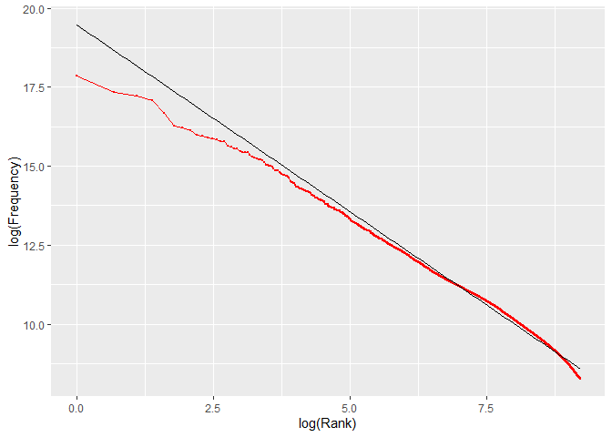

```r
ggplot(wikiDF, aes(x = log(Rank), y = log(Frequency))) +
    geom_point(col = 'red', size = 0.5) +
    geom_line(col = 'red', size = 0.5) +
    geom_smooth(method = "lm", col = 'black', size = 0.5)
```

A sidenote, notice how I make the x-axis and the y-axis a log scale. One little property of Zipf’s law is, if you make a log-log plot with the axes (i.e. you take the log of both the y axis and the x axis), it’ll look *somewhat* linear. Here, I’ve made a linear regression line to fit the data, and notice that it doesn’t exactly fit the data. If anything, it intercepts the “curve” twice.

This graph is not important for our purposes, as it delves into the mathematical component of Zipfian distribution. I’m not too well versed in the mathematics, but I just wanted to make this graph to illustrate the interesting property that rank-frequency graphs have.

At least, we now have our data frame to work with. Let’s make a plot that looks like the one we made earlier for Japanese words.

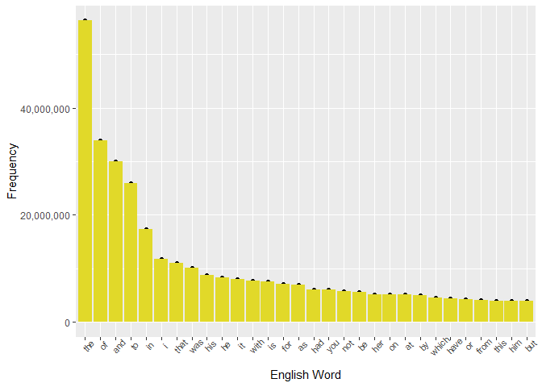

Let’s now get data from Twitter. I choose Twitter because it has a readily available API to work with. This API can be utilized via tweepy, a Python package.